# Analyzing Ad Lengths and Viewer Experience

## Distribution of Ad Lengths Based on Prior Exposure?

This box plot compares different ad lengths based on if you have seen the ad before. At first glance it might seem like the two do not correlate however it potentially could have shown that companys with longer ads also could have ad a bigger budget therefore buying more ads for Youtube to play. However this is not proven from the graph as the seen before graphs are only slightly higher in length.

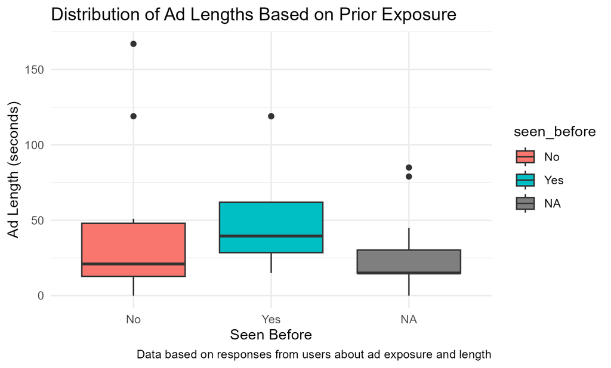

## Average Ad Length by Ad Type

This bar graph is showing the average ad length sorted by the ad type. I filtered out non video ads because they had a time of zero seconds which was a waste of space on the plot. As seen in this plot the skippable ads have a much higher ad length. This is due to unskippable ads most likely being required to be short by youtube so viewers dont click away when given a 60 second unskippable ad.

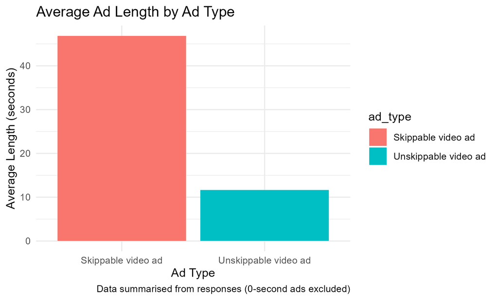

A bar plot showing average ad length where skippible ad lengths are much higher

## Density plot of ad lengths

This density plot shows that at around the 15 second mark is the highest density of ad length, this could be because of its the most common ad length for non skippable ads showing the high density while ads that can be skipped are highly variable as they can range from 15 to 120 seconds.

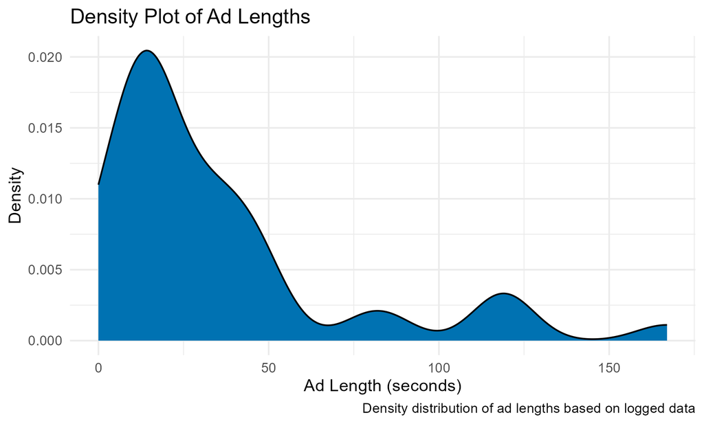

A density plot showing the density of different ad lengths where its very dense at around 15 seconds